# Fundamentals of `plot_ly()`

A Practitioner’s Guide

Cheng Peng

West Chester University

# 1 Introduction

Although we’re already comfortable with ggplot2, learning plotly is still worthwhile as an interactive complement. With `ggplotly()`, we can instantly add hover, zoom, and pan to your existing ggplot2 graphics with minimal effort. But learning the native `plot_ly()` syntax unlocks plotly’s full potential including 3D plots, animated time series, financial charts, and linked brushing which `ggplotly()` cannot fully replicate. We don’t need to abandon ggplot2; just add plotly when interactivity, dashboards, or data exploration for non-technical audiences is the goal. Mastering both `ggplotly()` for quick upgrades and `plot_ly()` for custom interactivity makes you a more versatile visualizer.

## 1.1 `ggplot()` Recap

ggplot2 is built on Wilkinson’s Grammar of Graphics and implements a declarative, compositional DSL (domain-specific language). A ggplot2 plot is not a simple data structure. It’s a deeply nested *S3 object* of class ggplot that contains:

- **data**: The original dataset (or datasets, if different layers use different data)
- **mapping**: Default aesthetic mappings (using aes())
- **layers**: A list of layer objects, each containing a geom, stat, position adjustment, and optional local data and aesthetic mappings
- **scales**: Objects that control how data values are mapped to visual properties
- **coordinates**: The coordinate system (Cartesian, polar, map projections, etc.)
- **facets**: Specifications for creating small multiples
- **theme**: A complete theming system with fine-grained control over every visual element

The ggplot2 object is built incrementally using the + operator. Each call adds a new component:

```r
p <- ggplot(mpg, aes(displ, hwy)) +        # Initialize with data and base mapping
  geom_point(aes(color = class)) +         # Add a layer (points)
  geom_smooth() +                          # Add another layer (smooth line)
  scale_color_brewer(palette = "Set1") +   # Modify scales
  theme_minimal() +                        # Apply theme
  facet_wrap(~ year)                       # Create facets
```

The plot is only rendered when printed. Until then, p is a specification—a description of what should be drawn, not a drawing itself.

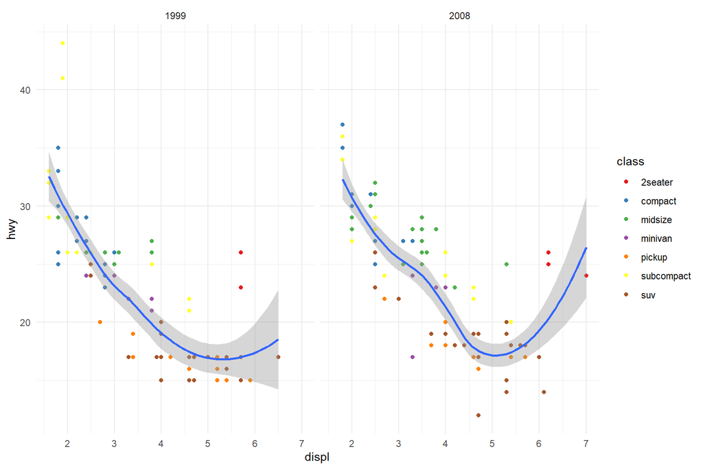

```r
print(p)
```

# 2 The Figure Structure & Core Components of plotly

In Plotly, every figure is structured as a **list-like object** with three top-level attributes. This structure is the key to building reusable components.

- **data**: This is a list of “**traces**”. A **trace** is simply a set of related graphical marks with a specific type, such as *scatter*, *bar*, or *line*. Each trace contains its own data arrays (x, y, text, marker properties) and type-specific styling. **Multiple traces** can be overlaid in the same figure , and each can be independently styled, controlled, and created based on different data sets.
- **layout**: This **controls everything** outside the data traces - the title, axes, legend, margins, background colors, shapes, annotations, and hover behaviors. The layout is a single object (not a list) that defines the canvas on which traces are drawn.
- **frames**: This attribute is used for creating animations, defining sequential frames of a plot. Each frame contains its own data and layout modifications, allowing you to create smooth transitions, sliders, and playback controls.

The following discussions on individual attrobite are based on a practitioner’s mental model view.

## 2.1 Traces (data)

A **trace** is one visual layer representing a coherent subset of your data. In a scatterplot with a regression line, the points are one trace and the line is another. Each trace is defined by:

| Trace Component | Description | Common Values |
| --- | --- | --- |
| `type` | Type of graphical representation | `"scatter"`, `"bar"`, `"box"`, `"histogram"`, `"heatmap"`, `"choropleth"` |
| **Data mapping** | Variables mapped to visual attributes | `x`, `y`, `z`, `color`, `size`, `symbol`, `frame`, `ids`, `text`, `customdata` |
| `mode` | How scatter-like traces are displayed | `"markers"`, `"lines"`, `"markers+lines"`, `"text"` |
| **Appearance** | Visual styling parameters | `marker`, `line`, `fill`, `stackgroup` |

**Key principles for real analysis**:

One trace per meaningful group works best for interactive legends, filtering, and custom hover. If color aesthetics create implicit grouping via color inside a single trace, plotly may still separate them internally, but explicit split or multiple add_trace() calls give you more control.

**Example: One trace per species for full legend control**

```r
iris %>%
  group_by(Species) %>%
  do(p = plot_ly(., x = ~Sepal.Length, y = ~Petal.Length,
                 type = "scatter", mode = "markers",
                 name = ~unique(Species),
                 marker = list(size = 10, opacity = 0.7))) %>%
  subplot(nrows = 1, shareX = TRUE, shareY = TRUE) %>%
  layout(title = "One trace per species — explicit control",
         xaxis = list(title = "Sepal Length"),
         yaxis = list(title = "Petal Length"))
```

[interactive chart not shown]

```r
# Alternative using add_trace() idiom:
plot_ly() %>%
  add_trace(data = filter(iris, Species == "setosa"),
            x = ~Sepal.Length, y = ~Petal.Length,
            type = "scatter", mode = "markers", name = "setosa",
            marker = list(size = 10, opacity = 0.7)) %>%
  add_trace(data = filter(iris, Species == "versicolor"),
            x = ~Sepal.Length, y = ~Petal.Length,
            type = "scatter", mode = "markers", name = "versicolor",
            marker = list(size = 10, opacity = 0.7)) %>%
  add_trace(data = filter(iris, Species == "virginica"),
            x = ~Sepal.Length, y = ~Petal.Length,
            type = "scatter", mode = "markers", name = "virginica",
            marker = list(size = 10, opacity = 0.7)) %>%
  layout(title = "Explicit traces — each independently stylable")
```

[interactive chart not shown]

**Custom data hiding**: every trace can carry invisible data (customdata, hovertext, ids, key) that powers advanced interactions (drill-down, cross-filtering, linking) without cluttering the visual encoding.

**Example**: Storing invisible customdata for later JavaScript use

```r
mtcars_with_id <- mtcars %>%
  tibble::rownames_to_column("car_id") %>%
  mutate(custom_info = paste(car_id, "|", mpg, "MPG |", hp, "HP"))

plot_ly(mtcars_with_id,
        x = ~wt, y = ~mpg,
        type = "scatter", mode = "markers",
        customdata = ~custom_info,    # invisible, available in plotly_hover/click events
        text = ~car_id,               # visible in tooltip
        hoverinfo = "text") %>%
  layout(title = "customdata stores extra information for interactivity")
```

[interactive chart not shown]

**Trace-level animation**: the frame aesthetic inside plot_ly() links each row to an animation frame, enabling smooth transitions when combined with an animation slider.

**Example**: Gapminder-style animated bubble chart

```r
#library(plotly)

plot_ly(gapminder,
        x = ~gdpPercap, y = ~lifeExp,
        size = ~pop, color = ~continent,
        frame = ~year,
        text = ~country,
        hoverinfo = "text",
        type = "scatter", mode = "markers",
        marker = list(sizemode = "diameter", sizeref = 0.9)) %>%
  layout(
    title = list(
      text = "Global Development Trends (1952-2007)",
      font = list(size = 16),
      x = 0.5,
      xanchor = "center"
    ),
    margin = list(l = 80, r = 80, t = 120, b = 80),
    xaxis = list(
      type = "log",
      title = "GDP per Capita (log scale)",
      automargin = TRUE,
      domain = c(0, 1)  # Legend doesn't reduce plot width
    ),
    yaxis = list(
      title = "Life Expectancy (years)",
      automargin = TRUE,
      range = c(20, 85),
      domain = c(0.15, 1)  # Shrink plot height to create space above
    ),
    legend = list(
      title = list(text = "Continent"),
      orientation = "h",
      x = 0.5,
      y = 1.1,  # Position in the newly created top margin
      xanchor = "center",
      yanchor = "top",
      bgcolor = "rgba(255, 255, 255, 0.9)",
      bordercolor = "#cccccc",
      borderwidth = 0
    )
  ) %>%
  #animation_opts(frame = 800, transition = 800) %>%
   animation_opts(
          frame = 800,              # Each frame lasts 0.8 seconds
          transition = 800,         # Long smooth transition (0.8 seconds)
          #easing = "quadratic-in-out",  # Smooth start and end
          redraw = FALSE,           # Don't redraw entire plot
          mode = "immediate"        # Start playing automatically
  )%>%
  animation_slider(currentvalue = list(prefix = "Year: ")) %>%
  animation_button(
       label = "Play",
       method = "animate",
       args = list(
           list(
               frame = list(duration = 500, redraw = FALSE),
               transition = list(duration = 300),
               mode = "immediate",
               fromcurrent = TRUE
              ),
          list(
              loop = TRUE,          # THIS MAKES IT LOOP CONTINUOUSLY
              frame = list(duration = 500)
        )
      )
   )
```

[interactive chart not shown]

## 2.2 Layout

The layout object governs everything that is not a data mark: axes, annotations, shapes, titles, legends, hover behaviour, margins, and responsive sizing.

## 2.3 Essential layout elements

**Axes**: accessed via `layout(xaxis = list(...), yaxis = list(...))`.

| Property | Description | Example |
| --- | --- | --- |
| `title` | Axis title (string or list for font control) | `list(text = "Revenue", font = list(size = 14))` |
| `range` | Fixed numeric range | `c(20000, 80000)` |
| `type` | Scale type | `"-"`, `"log"`, `"date"`, `"category"` |
| `tickformat` | d3 formatting string | `"$,.0f"`, `".1%"` |
| `showspikes` | Crosshair reference lines on hover | `TRUE` / `FALSE` |
| `zeroline` | Line at zero | `TRUE` / `FALSE` |
| `gridcolor` | Grid line colour | `"#e5e5e5"` |

**Example**: Publication-style axes with spikes and formatted ticks

```r
set.seed(123)
sales_data <- data.frame(
  month = seq(as.Date("2024-01-01"), as.Date("2024-12-01"), by = "month"),
  revenue = cumsum(rnorm(12, mean = 5000, sd = 1000))
)

plot_ly(sales_data, x = ~month, y = ~revenue,
        type = "scatter", mode = "lines+markers",
        marker = list(size = 8, color = "#1f77b4"),
        line = list(width = 2.5, dash = "solid")) %>%
  layout(
    title = "Monthly Revenue, 2024",
    xaxis = list(
      title = list(text = "Month", font = list(size = 14, family = "Arial")),
      type = "date",
      tickformat = "%b %Y",
      gridcolor = "#e5e5e5",
      gridwidth = 0.5,
      showspikes = TRUE,          # crosshair spike on hover
      spikethickness = 0.8,
      spikedash = "dot",
      spikecolor = "#999999",
      showline = TRUE,
      linewidth = 1,
      linecolor = "black"
    ),
    yaxis = list(
      title = list(text = "Revenue", font = list(size = 14)),
      tickformat = "$,.0f",      # dollar format with comma separator
      range = c(20000, 80000),   # fixed range for comparison
      zeroline = TRUE,
      zerolinecolor = "#d9d9d9",
      gridcolor = "#e5e5e5",
      showline = TRUE,
      linewidth = 1,
      linecolor = "black"
    )
  )
```

[interactive chart not shown]

**Multi-axis layouts**: xaxis2, yaxis2, …, yaxis5 etc., with `overlaying = "x"` or “y” and side = `"right"` or `"top"`. Use `anchor = "free"` for fully custom positioning.

**Example**: Dual y-axes — temperature and precipitation

```r
library(plotly)

climate <- data.frame(
  month_num = 1:12,
  month = c("Jan", "Feb", "Mar", "Apr", "May", "Jun",
            "Jul", "Aug", "Sep", "Oct", "Nov", "Dec"),
  temp = c(2, 3, 7, 12, 18, 22, 25, 24, 20, 14, 8, 4),
  precip = c(50, 40, 55, 60, 70, 75, 70, 65, 60, 55, 45, 48)
)

climate$month <- as.character(climate$month)

plot_ly(climate, x = ~month_num) %>%
  add_trace(y = ~temp, type = "bar", name = "Temperature (C)",
            marker = list(color = "steelblue",
                          line = list(color = "steelblue", width = 1.5)),
            yaxis = "y") %>%
  add_trace(y = ~precip, type = "scatter", mode = "line+markers",
            name = "Precipitation (mm)",
            line = list(color = "purple4", width = 3),
            marker = list(color = "purple", size = 8),
            yaxis = "y2") %>%
  layout(
    title = "Monthly Climate Summary",
    margin = list(l = 80, r = 80, t = 100, b = 80),  # Increased margins
    yaxis = list(title = "Temperature (C)",
                 side = "left",
                 showgrid = FALSE,
                 zeroline = FALSE,
                 automargin = TRUE),  # Auto-adjust margin for labels
    yaxis2 = list(title = "Precipitation (mm)",
                  overlaying = "y",
                  side = "right",
                  showgrid = FALSE,
                  zeroline = FALSE,
                  automargin = TRUE),  # Auto-adjust margin for right axis
    xaxis = list(title = "Month",
                 tickmode = "array",
                 tickvals = 1:12,
                 ticktext = climate$month,
                 tickangle = -45,  # Rotate labels to prevent overlap
                 automargin = TRUE),  # Auto-adjust margin for x-axis
    legend = list(x = 0.1, y = 0.95)
  )
```

[interactive chart not shown]

**Legend positioning**: layout(legend = list(orientation = “h”, x = 0.5, xanchor = “center”, y = -0.1)) for bottom-aligned legends; groupclick and itemclick control what happens when a user clicks legend items (toggle visibility, isolate, nothing).

**Example**: Bottom-aligned legend with custom interaction

```r
plot_ly(mtcars, x = ~wt, y = ~mpg, color = ~factor(cyl),
        type = "scatter", mode = "markers",
        marker = list(size = 12, opacity = 0.8),
        text = ~paste("Car:", rownames(mtcars), "<br>HP:", hp),
        hoverinfo = "text") %>%
  layout(
    legend = list(
      orientation = "h",
      x = 0.5, xanchor = "center",
      y = -0.15,
      title = list(text = "Cylinders"),
      itemclick = "toggleothers",  # isolate clicked trace
      itemdoubleclick = "toggle"   # re-add others
    ),
    margin = list(b = 80)  # extra bottom margin for legend
  )
```

[interactive chart not shown]

Annotations and shapes: two of the most powerful storytelling tools. Annotations can contain HTML, use arrow pointers to specific data coordinates, and be positioned relative to paper (“paper”) or axes (“x”/“y”). Shapes (rectangles, circles, lines) can highlight regions of interest, define confidence bands manually, or draw attention to thresholds.

**Example**: Annotations and shapes for storytelling — highlighting a threshold

```r
set.seed(42)
process <- data.frame(
  batch = 1:50,
  purity = c(rnorm(40, mean = 95, sd = 1.5), rnorm(10, mean = 89, sd = 2))
)
threshold <- 92

plot_ly(process, x = ~batch, y = ~purity,
        type = "scatter", mode = "lines+markers",
        marker = list(size = 6, color = "steelblue"),
        line = list(color = "steelblue", width = 1.5)) %>%
  # Add threshold line as a shape
  layout(
    title = "Product Purity by Batch — Out-of-Spec Investigation",
    shapes = list(
      # Horizontal threshold line
      list(type = "line",
           x0 = 0, x1 = 51, y0 = threshold, y1 = threshold,
           line = list(color = "red", width = 2, dash = "dash")),
      # Shaded region for out-of-spec batches
      list(type = "rect",
           x0 = 40, x1 = 51, y0 = 80, y1 = 100,
           fillcolor = "rgba(255, 0, 0, 0.1)", line = list(width = 0))
    ),
    annotations = list(
      # Text annotation for threshold
      list(x = 3, y = threshold + 0.5,
           text = paste("Spec limit:", threshold, "%"),
           showarrow = FALSE,
           font = list(color = "red", size = 11)),
      # Arrow annotation pointing to the problem
      list(x = 48, y = 87,
           text = "Out-of-spec<br>batches detected",
           showarrow = TRUE,
           arrowhead = 2,
           arrowsize = 1,
           ax = 20, ay = -30,
           font = list(color = "darkred", size = 12, family = "Arial"))
    ),
    xaxis = list(title = "Batch Number"),
    yaxis = list(title = "Purity (%)")
  )
```

[interactive chart not shown]

Responsive sizing: layout(autosize = TRUE) combined with CSS on the container is the default. For fixed aspect, set width and height. For dashboards, margin = list(l=50, r=20, t=60, b=50) helps maximise data ink.

**Example**: Responsive plot with trimmed margins

```r
plot_ly(economics, x = ~date, y = ~unemploy,
        type = "scatter", mode = "lines",
        line = list(color = "#2ca02c", width = 1.5)) %>%
  layout(
    title = "U.S. Unemployment",
    autosize = TRUE,                  # responsive to container
    margin = list(l = 50, r = 20, t = 50, b = 40),  # compact margins
    xaxis = list(title = ""),
    yaxis = list(title = "Number Unemployed", tickformat = ",.0f")
  )
```

[interactive chart not shown]

## 2.4 Frames & Animation

For visual storytelling with temporal data, frames hold snapshots of the trace data at each animation step. The plot_ly() mapping usually includes frame = ~time_var. Control the playback with:

| Animation Control | Description | Example |
| --- | --- | --- |
| `animation_opts()` | Frame duration, transition, easing | `animation_opts(frame = 500, transition = 300, easing = "cubic-in-out")` |
| `animation_slider()` | Slider appearance and labels | `animation_slider(currentvalue = list(prefix = "Year: "))` |
| `animation_button()` | Custom play button | `animation_button(label = "▶ Play")` |

Real-world tip: pre-compute all aesthetics per frame explicitly rather than relying on the frame aesthetic to interpolate complex transformations. This avoids unexpected morphing.

**Example**: Sales by quarter with explicit pre-computed ranking

```r
# Pre-compute ranks per frame for consistent bar ordering
sales_anim <- expand.grid(quarter = paste0("Q", 1:4),
                           product = LETTERS[1:5]) %>%
  mutate(sales = round(runif(20, 100, 1000))) %>%
  group_by(quarter) %>%
  mutate(rank = rank(-sales, ties.method = "first")) %>%
  ungroup()

plot_ly(sales_anim,
        x = ~sales, y = ~reorder(product, -sales),
        frame = ~quarter,
        type = "bar", orientation = "h",
        marker = list(color = ~sales, colorscale = "Viridis",
                      colorbar = list(title = "Sales"))) %>%
  layout(title = "Quarterly Sales by Product",
         xaxis = list(title = "Revenue ($)"),
         yaxis = list(title = "")) %>%
  animation_opts(frame = 1200, transition = 800, easing = "elastic-out") %>%
  animation_slider(currentvalue = list(prefix = "Quarter: ")) %>%
  animation_button(label = "▶ Play", x = 0.1, y = 0)
```

[interactive chart not shown]

# 3 The Functional Pipeline Model

The **Functional Pipeline Model** is a programming paradigm where:

- Data/objects flow through a sequence of functions
- Each function transforms the input and passes it forward
- The original object is preserved (or appears preserved) through immutability
- Operations are **chainable** in a linear, readable sequence

In R, this is primarily implemented through:

- The `%>%` pipe operator (from magrittr, now native `|>`)
- Functions that take an object as first argument and return a modified copy

**The mathematical/Conceptual Foundation**

```
# Consider the compund function
final_result = fn3(fn2(fn1(initial_object)))

# Becomes with piping:
initial_object %>%
  fn1() %>%
  fn2() %>%
  fn3()
```

The R plotly API is built around the idea of successive modifications via %>%:

```
p <- plot_ly(data, x = ~var1, y = ~var2, type = "scatter", mode = "markers")
p <- add_trace(p, x = ~var1, y = ~fitted, mode = "lines", name = "Trend")
p <- layout(p, title = "My Plot", xaxis = list(title = "Predictor"))
p <- colorbar(p, title = "Intensity")   # for traces that have a colour scale
```

This pipeline mirrors the immutable JSON structure: each function returns a new figure object with the appropriate data or layout slot modified. Understanding this prevents confusion about why some styling arguments are inside plot_ly() and others in layout() or colorbar().

**Example**: Building a plot step by step through the pipeline. We will explain the steps in details in the following.

**Step 1**: Base plot - scatter plot

```r
# Create a Plotly figure object using the Functional Pipeline Model
# NOTE: This is the initial creation step - we're starting a pipeline
# that could be extended with %>% operations
p <- plot_ly(
  # ---- DATA ARGUMENT (implicit first argument) ----
  mtcars,                           # Using the built-in mtcars dataset (32 cars)
                                    # This is the data source that gets stored
                                    # in the figure object as the reference data

  # ---- AESTHETIC MAPPINGS (using formula notation) ----
  x = ~hp,                          # Map x-axis to horsepower (hp column)
                                    # The ~ creates a formula object
                                    # plotly evaluates this in the context of mtcars
                                    # Equivalent to: mtcars$hp
                                    # Range: 52-335 hp in this dataset

  y = ~qsec,                        # Map y-axis to quarter mile time (qsec column)
                                    # qsec = time to travel 1/4 mile in seconds
                                    # This measures acceleration performance
                                    # Range: 14.5-22.9 seconds

  # ---- TRACE TYPE DEFINITION ----
  type = "scatter",                 # Specify the trace type
                                    # "scatter" creates a scatter plot trace
                                    # This is a fundamental plotly trace type
                                    # Other options: "bar", "line", "histogram", etc.
                                    # Each trace type has specific visual properties

  # ---- DISPLAY MODE ----
  mode = "markers",                 # How to display the data points
                                    # "markers" = points only (no connecting lines)
                                    # Other options: "lines", "lines+markers", "text"
                                    # This controls the visual representation

  # ---- MARKER AESTHETICS (nested list for detailed control) ----
  marker = list(                    # Customize the point markers appearance
    size = 10,                      # Marker size in pixels (default is typically 6)
                                    # Size 10 makes points more prominent
                                    # This is a fixed size, not mapped to data

    opacity = 0.6                   # Transparency level (0 = fully transparent, 1 = fully opaque)
                                    # 0.6 = 60% opaque, 40% transparent
                                    # Useful for seeing overlapping points
                                    # When points overlap, they'll appear darker
  ),

  # ---- TRACE IDENTIFICATION ----
  name = "Observed"                 # Name/label for this trace
                                    # Appears in legend and hover tooltips
                                    # Descriptive name helps viewers understand the data
                                    # This creates a trace named "Observed" in the legend
)
p  # view step 1
```

[interactive chart not shown]

**Step 2**: add a LOESS (Locally Estimated Scatterplot Smoothing) smooth curve

```r
# Fit a LOESS (Locally Estimated Scatterplot Smoothing) model
# predicting qsec (1/4 mile time) from hp (horsepower) using mtcars dataset
fit <- loess(qsec ~ hp, data = mtcars)

# Create a sequence of 100 equally spaced hp values from min to max
# This provides a smooth curve when plotted
hp_seq <- seq(min(mtcars$hp), max(mtcars$hp), length.out = 100)

# Generate predicted qsec values from the LOESS model for each hp in the sequence
fit_pred <- predict(fit, newdata = data.frame(hp = hp_seq))

# Add the LOESS smooth line to an existing plot object 'p'
p <- add_trace(p,
               x = hp_seq,           # x-coordinates (horsepower values)
               y = fit_pred,         # y-coordinates (predicted qsec values)
               type = "scatter",     # scatter plot type (but with lines mode)
               mode = "lines",       # display as connected lines (no points)
               line = list(          # line styling options
                 color = "red",      # set line color to red
                 width = 2.5,        # set line thickness to 2.5 points
                 dash = "dash"       # use dashed line style
               ),
               name = "LOESS Smooth" # legend label for this trace
)
p  # view step 2
```

[interactive chart not shown]

**Step 3** - Polish layout - Addint title, labels of axes, legend, etc.

```r
# Step 3: polish layout
# Update the layout of existing plot object 'p' with custom styling
p <- layout(p,
            # Main plot title - describes the relationship being visualized
            title = "Quarter Mile Time vs. Horsepower",
            # X-axis configuration
            xaxis = list(
              title = "Horsepower (hp)",  # Axis label with units
              zeroline = FALSE            # Remove zero reference line for cleaner look
            ),
            # Y-axis configuration
            yaxis = list(
              title = "Quarter Mile Time (sec)",  # Axis label with units
              zeroline = FALSE                    # Remove zero reference line
            ),
            # Legend positioning
            legend = list(
              x = 0.75,    # Horizontal position (0=left, 1=right) - places legend right of center
              y = 0.95     # Vertical position (0=bottom, 1=top) - places legend near top
            )
      )

p  # final plot
```

[interactive chart not shown]

**Visual Summary of the Pipeline Architecture** - Conceptual visualization of what `plot_ly()` builds:

```
 ┌─────────────────────────────────┐
 │     Plotly Figure Object        │
 ├─────────────────────────────────┤
 │ Data: mtcars                    │  ← Reference to source data
 ├─────────────────────────────────┤
 │ Trace 1 ("Observed"):           │
 │   x mapping: ~hp                │  ← Horsepower values
 │   y mapping: ~qsec              │  ← Quarter mile times
 │   type: scatter                 │  ← Scatter plot
 │   mode: markers                 │  ← Show as points
 │   marker:                       │
 │     size: 10                    │  ← 10px diameter
 │     opacity: 0.6                │  ← 60% opaque
 ├─────────────────────────────────┤
 │ Layout: (empty, uses defaults)  │  ← Can be modified later
 ├─────────────────────────────────┤
 │ Config: (empty, uses defaults)  │  ← Interactive behavior
 └─────────────────────────────────┘
```

This code demonstrates the foundational step of the Functional Pipeline Model - creating an initial figure object that encapsulates all the visualization state and is ready for further transformation through the pipeline.

```r
p <- plot_ly(mtcars,
             x = ~hp,                                  #
             y = ~qsec,
             type = "scatter",
             mode = "markers",
             marker = list(size = 10, opacity = 0.6),
             name = "Observed") %>%
      add_trace(                              # Add a SECOND trace
             x = ~hp,
             y = ~predict(lm(qsec ~ hp, data = mtcars)),
             type = "scatter",
             mode = "lines",                  # Lines for the regression
             name = "Fitted") %>%             # Second trace labeled "Fitted"

      layout(                             # Configure the layout
             title = "Quarter Mile Time vs Horsepower\nwith Linear Regression Fit",
             xaxis = list(title = "Horsepower (hp)"),
             yaxis = list(title = "Quarter Mile Time (seconds)")
     )
```

# 4 Embedding Graphical Objects for Storytelling

For intermediate analysts, the ability to embed external images such as company logos or explanatory icons alongside mathematical notation directly into a visualization is a hallmark of a polished, self-contained data product.

To add images, use the images attribute inside `layout()`. However, the coordinate system is critical: we must understand the difference between paper coordinates (relative to the plotting area) and data coordinates (relative to the axes) to position your images correctly

| Parameter | Description | Values |
| --- | --- | --- |
| `xref`, `yref` | Coordinate reference system | `"paper"` (0–1 plot area) or `"x"`/`"y"` (data coordinates) |
| `sizex`, `sizey` | Image size in axis units | 0.05 = 5% of plot width (paper coordinates) |
| `xanchor`, `yanchor` | Alignment of image bounding box | `"left"`, `"center"`, `"right"` / `"top"`, `"middle"`, `"bottom"` |
| `x`, `y` | Position coordinates | Depends on reference system |
| `opacity` | Image transparency | 0 (fully transparent) to 1 (fully opaque) |

**Practical example** — logo in top-right:

```r
# Create an interactive scatter plot with an embedded image/logo overlay

plot_ly(mtcars,                      # Use built-in mtcars dataset
        x = ~wt,                     # Weight (1000 lbs) on x-axis
        y = ~mpg,                    # Miles per gallon on y-axis
        type = "scatter",            # Scatter plot type
        mode = "markers") %>%        # Display as points only (no lines)

  # Add layout customizations including an overlaid image
  layout(
    # Main plot title
    title = "Vehicle Efficiency Analysis",

    # List of images to overlay on the plot
    images = list(
      list(
        # URL of the image to display (Plotly R logo)
        source = "https://images.plot.ly/language-icons/api-home/r-logo.png",

        # Coordinate references: "paper" uses normalized coordinates (0-1 range)
        xref = "paper", yref = "paper",

        # Image position: top-right corner (x=1, y=1)
        x = 1, xanchor = "right",    # Right-align at x=1 (right edge)
        y = 1, yanchor = "top",      # Top-align at y=1 (top edge)

        # Image size as proportion of plot area (20% width, 20% height)
        sizex = 0.2, sizey = 0.2,

        # Transparency level (0 = fully transparent, 1 = fully opaque)
        opacity = 0.8
      )
    )
  )
```

[interactive chart not shown]

**Example**: Placing an icon at a specific data coordinate

```r
plot_ly(mtcars, x = ~wt, y = ~mpg, type = "scatter", mode = "markers") %>%
  layout(
    images = list(
      list(
        source = "https://upload.wikimedia.org/wikipedia/commons/thumb/4/4f/Highway_1_%28MUTCD%29.svg/320px-Highway_1_%28MUTCD%29.svg.png",
        xref = "x", yref = "y",        # data coordinates
        x = 3, y = 30,                 # position at wt=3, mpg=30
        sizex = 1, sizey = 8,          # size in axis units
        xanchor = "center",
        yanchor = "middle"
      )
    ),
    xaxis = list(title = "Weight (1000 lbs)"),
    yaxis = list(title = "Miles per Gallon")
  )
```

[interactive chart not shown]

# 5 Popups and Tooltip Hover Messages

The hover tooltip is your primary channel for delivering “details on demand”. In real-world analysis, raw default tooltips (x and y values only) are rarely sufficient; you need to surface context variables, units, percentage change, or categorical metadata.

## 5.1 The text + hoverinfo Approach

Build a custom character vector in your dataset that contains everything you want to display, using HTML tags (`<br>` for line breaks, `<b>` for bold, `<i>` for italics). Map it to the text aesthetic and set `hoverinfo = "text"`.

**Advantages of `text` + `hoverinfo`**:

- Complete control over formatting and contents
- Can include variables not directly plotted
- Works identically for all trace types

**Real-world pattern**:

```r
# Simulate quarterly sales by region
sales_df <- expand.grid(
  quarter = paste0("Q", 1:4),
  region = c("North", "South", "East", "West")
) %>%
  mutate(
    sales = round(runif(16, 50000, 200000)),
    prev_year_sales = round(runif(16, 45000, 180000)),
    yoy_change = (sales - prev_year_sales) / prev_year_sales,
    margin = runif(16, 0.15, 0.45)
  ) %>%
  mutate(
    tooltip = paste0(
      "<b>", region, "</b><br>",
      "Quarter: ", quarter, "<br>",
      "Sales: ", dollar(sales), "<br>",
      "YoY Change: ", percent(yoy_change, accuracy = 0.1), "<br>",
      "Margin: ", number(margin * 100, accuracy = 0.1), "%"
    )
  )

plot_ly(sales_df, x = ~quarter, y = ~sales,
        color = ~region, type = "scatter", mode = "lines+markers",
        text = ~tooltip, hoverinfo = "text",
        marker = list(size = 10),
        line = list(width = 2.5)) %>%
  layout(
    title = "Quarterly Sales Performance",
    xaxis = list(title = "Quarter"),
    yaxis = list(title = "Sales", tickformat = "$,.0f"),
    hovermode = "closest"
  )
```

[interactive chart not shown]

## 5.2 `hovertemplate` – Concise and Formatting-Powerful

A d3-inspired template string using %{variable:format} placeholders. Less flexible for nested HTML structures but very readable for quick customisation.

```r
plot_ly(sales_df, x = ~quarter, y = ~sales, color = ~region,
        type = "scatter", mode = "lines+markers",
        hovertemplate = ~paste(
          '<b>%{text}</b><br>',           # accesses text variable
          'Sales: $%{y:,.0f}<br>',
          'QoQ Change: %{customdata:.1%}',
          '<extra></extra>'               # suppresses trace name box
        ),
        text = ~region,
        customdata = ~yoy_change,         # extra data for template
        marker = list(size = 10),
        line = list(width = 2.5)) %>%
  layout(
    title = "Quarterly Sales — Clean Hover Template",
    xaxis = list(title = "Quarter"),
    yaxis = list(title = "Sales ($)", tickformat = "$,.0f")
  )
```

[interactive chart not shown]

## 5.3 Hover Mode & Unified Hover

| Hover Mode | Description | Best Use Case |
| --- | --- | --- |
| `"closest"` (default) | Tooltip for nearest point | General scatter plots |
| `"x unified"` | All y-values at a given x in one tooltip | Time series with multiple series |
| `"y unified"` | Unified across a y-value | Horizontal comparisons |
| `FALSE` or `"none"` | Disables tooltips entirely | When using custom JavaScript events |

Unified hover works best when traces have the same x values and when hoverlabel formatting (e.g., bgcolor, font) is set consistently across traces.

**Example**: Unified hover for time series comparison

```r
# Simulate portfolio values
dates <- seq(as.Date("2024-01-01"), as.Date("2024-12-01"), by = "month")
set.seed(789)
portfolio <- data.frame(
  date = rep(dates, 3),
  asset = rep(c("Equities", "Bonds", "Commodities"), each = length(dates)),
  value = c(cumprod(1 + rnorm(length(dates), 0.008, 0.03)) * 10000,
            cumprod(1 + rnorm(length(dates), 0.003, 0.01)) * 10000,
            cumprod(1 + rnorm(length(dates), 0.005, 0.04)) * 10000)
)

plot_ly(portfolio, x = ~date, y = ~value, color = ~asset,
        type = "scatter", mode = "lines",
        line = list(width = 2),
        hovertemplate = ~paste(
          '<b>%{text}</b><br>',
          'Value: $%{y:,.0f}',
          '<extra></extra>'
        ),
        text = ~asset) %>%
  layout(
    title = "Portfolio Performance — Hover to Compare",
    hovermode = "x unified",      # all traces at same x in one tooltip
    hoverlabel = list(
      bgcolor = "white",
      font = list(size = 12, family = "Arial")
    ),
    xaxis = list(title = "", tickformat = "%b %Y"),
    yaxis = list(title = "Portfolio Value", tickformat = "$,.0f")
  )
```

[interactive chart not shown]

## 5.4 Custom Interactivity: Using `customdata` + JavaScript Events

For Shiny dashboards or standalone HTML widgets with custom callbacks, store extra data in customdata (a matrix or list-column accessible in JavaScript) and use plotly_hover / plotly_click events. This enables updating side panels, triggering drill-downs, or showing images on hover without any tooltip box.

**Example**: Click event that updates Shiny output (Shiny app pattern)

```
# In Shiny app:
#
# ui <- fluidPage(
#   plotlyOutput("scatter"),
#   verbatimTextOutput("click_info")
# )
#
# server <- function(input, output, session) {
#   output$scatter <- renderPlotly({
#     mtcars$car_name <- rownames(mtcars)
#     plot_ly(mtcars, x = ~wt, y = ~mpg,
#             type = "scatter", mode = "markers",
#             customdata = ~car_name,    # stored for event
#             source = "scatter_plot") %>%   # namespaced for event
#       event_register("plotly_click")
#   })
#
#   output$click_info <- renderPrint({
#     event_data <- event_data("plotly_click", source = "scatter_plot")
#     if (is.null(event_data)) return("Click a point")
#     paste("You clicked:", event_data$customdata)
#   })
# }
```

**Standalone HTML example with custom JavaScript callback**:

```r
p <- plot_ly(mtcars, x = ~wt, y = ~mpg,
             type = "scatter", mode = "markers",
             customdata = rownames(mtcars),
             source = "demo_plot") %>%
  event_register("plotly_click")

# Add JavaScript that triggers on click
p <- htmlwidgets::onRender(p, "
  function(el, x) {
    el.on('plotly_click', function(data) {
      var point = data.points[0];
      alert('You clicked: ' + point.customdata +
            ' (wt=' + point.x.toFixed(2) +
            ', mpg=' + point.y.toFixed(1) + ')');
    });
  }
")
p
```

[interactive chart not shown]

# 6 3D Plotly Plots

Creating 3D visualizations in R with plotly opens up a new dimension for data exploration. By mapping a third variable to the z-axis, you can uncover patterns, clusters, or relationships that might be missed in 2D.

| Plot Type | Purpose & Use Case | Key type in plot_ly |
| --- | --- | --- |
| 3D Scatter Plot | Visualizing the relationship between three continuous variables. Excellent for identifying clusters or outliers in multivariate data. | `type = "scatter3d"` |
| 3D Line Plot | Tracking a trajectory through three-dimensional space. Useful for time-series data with three variables or tracing the path of an object. | `type = "scatter3d"`, `mode = "lines"` |
| 3D Surface & Mesh Plots | Representing a continuous surface over a grid. Ideal for visualizing mathematical functions, response surfaces in regression, or complex 3D shapes. | `type = "surface"` or `type = "mesh3d"` |
| 3D Globe/Map | Plotting geographical data on a spherical surface, such as storm tracks, flight paths, or global climate data. | Uses `add_surface()` with spherical coordinates |

## 6.1 Scatter 3D Plot

**Complete worked example**: Investigating the relationship between horsepower, weight, and fuel efficiency with model annotation

```r
# Build a linear model for annotation
fit <- lm(mpg ~ hp + wt, data = mtcars)
rsq <- round(summary(fit)$r.squared, 3)
coefs <- round(coef(fit), 2)

# Build rich tooltip
mtcars_viz <- mtcars %>%
  tibble::rownames_to_column("car") %>%
  mutate(tooltip = paste0(
    "<b>", car, "</b><br>",
    "Horsepower: ", hp, " hp<br>",
    "Weight: ", wt, " (1000 lbs)<br>",
    "Efficiency: ", mpg, " mpg<br>",
    "Cylinders: ", cyl
  ))

# Create the visualisation
plot_ly(mtcars_viz,
        x = ~hp, y = ~wt, z = ~mpg,
        type = "scatter3d", mode = "markers",
        marker = list(size = 7, opacity = 0.7,
                      color = ~mpg, colorscale = "Viridis",
                      colorbar = list(title = "MPG")),
        text = ~tooltip, hoverinfo = "text"
        ) %>%
  layout(
    title = list(
      text = "Vehicle Efficiency Landscape<br><sup>Interactive 3D Exploration</sup>",
      font = list(size = 16)
    ),
    scene = list(
      xaxis = list(title = "Horsepower (hp)"),
      yaxis = list(title = "Weight (1000 lbs)"),
      zaxis = list(title = "Miles per Gallon")
    ),
    images = list(
      list(source = "https://images.plot.ly/language-icons/api-home/r-logo.png",
           xref = "paper", yref = "paper",
           x = 0.02, y = 0.98,
           sizex = 0.12, sizey = 0.12,
           xanchor = "left", yanchor = "top")
    ),
    margin = list(l = 20, r = 20, t = 70, b = 40)
  )
```

[interactive chart not shown]

## 6.2 Surface with Scatter Overlay

This is useful for nonlinear durface fitting (i.e., multiple nonlinear regression models). For illustrative purpose, we provide a toy example below.

```r
library(plotly)

# Generate surface data
x_surf <- seq(-3, 3, length.out = 30)
y_surf <- seq(-3, 3, length.out = 30)
z_surf <- outer(x_surf, y_surf, function(x, y) {
  x^2 - y^2
})

# Generate random points on the surface with some noise
set.seed(123)
n_points <- 50
x_points <- runif(n_points, -3, 3)
y_points <- runif(n_points, -3, 3)
z_points <- x_points^2 - y_points^2 + rnorm(n_points, 0, 0.3)

# Create combined plot
plot_ly() %>%
  # Add the surface
  add_surface(
    x = ~x_surf, y = ~y_surf, z = ~z_surf,
    opacity = 0.7,
    colorscale = "Viridis",
    name = "Theoretical Surface"
  ) %>%
  # Add scatter points
  add_trace(
    x = x_points, y = y_points, z = z_points,
    type = "scatter3d", mode = "markers",
    marker = list(size = 5, color = "red", symbol = "circle"),
    name = "Observed Data"
  ) %>%
  layout(
    title = "Surface with Overlaid Scatter Data",
    scene = list(
      xaxis = list(title = "X"),
      yaxis = list(title = "Y"),
      zaxis = list(title = "Z"),
      camera = list(
        eye = list(x = 1.5, y = -1.5, z = 1.2)
      )
    ),
    legend = list(x = 0.05, y = 0.95)
  )
```

[interactive chart not shown]

# 7 Plotly Maps

Geo maps are are appropriate for creating choropleths and scatter plots on a clean, customizable outline of the world or a specific region.

## 7.1 Scatter Plot on a Geo Map

**Example**: This is great for plotting event locations, air traffic, or any data with latitude and longitude coordinates.

```r
library(plotly)

# Sample airport traffic data
df <- read.csv('https://raw.githubusercontent.com/plotly/datasets/master/2011_february_us_airport_traffic.csv')

# Geo styling options
g <- list(
  scope = 'usa',
  projection = list(type = 'albers usa'),
  showland = TRUE,
  landcolor = toRGB("gray95"),
  subunitcolor = toRGB("gray85"),
  countrycolor = toRGB("gray85")
)

fig <- plot_geo(df, lat = ~lat, lon = ~long)
fig <- fig %>% add_markers(
  text = ~paste(airport, city, state, paste("Arrivals:", cnt), sep = "<br />"),
  color = ~cnt,
  symbol = I("square"),
  hoverinfo = "text"
)
fig <- fig %>% colorbar(title = "Incoming flights<br />February 2011")
fig <- fig %>% layout(title = 'Most trafficked US airports', geo = g)

fig
```

[interactive chart not shown]

This creates an interactive map where marker color represents flight volume, and hovering shows airport details

## 7.2 Choropleth Map

Choropleth maps are ideal for showing data variations across predefined geographic regions like countries or counties.

**Example**: The choropleth map below shows US county-level unemployment rates for 2016.

```r
library(plotly)
library(rjson)

# Load GeoJSON data (county boundaries)
url <- 'https://raw.githubusercontent.com/plotly/datasets/master/geojson-counties-fips.json'
counties <- rjson::fromJSON(file=url)

# Load unemployment data
df <- read.csv("https://raw.githubusercontent.com/plotly/datasets/master/fips-unemp-16.csv",
               colClasses = c(fips="character"))

fig <- plot_ly()
fig <- fig %>% add_trace(
  type = "choropleth",
  geojson = counties,
  locations = df$fips,
  z = df$unemp,
  colorscale = "Viridis",
  zmin = 0,
  zmax = 12,
  marker = list(line = list(width = 0))
)
fig <- fig %>% layout(
  title = "US County Unemployment (2016)",
  geo = list(scope = 'usa')
)
fig
```

[interactive chart not shown]

# 8 ggplot or plotly?